# Introducción a distribuciones de probabilidad

Ramon Ceballos

8/2/2021

# **Distribución Exponencial**

## 1. Conceptos teóricos y matemáticos

Una v.a. continua $X$ tiene distribución exponencial de parámetro $\lambda$, **$X\sim\text{Exp}(\lambda)$**, si su función de densidad es:
$$f_X(x)=\left\{
\begin{array}{rl}
0 & \text{si } x\le 0
\\ \lambda\cdot e^{-\lambda x} & \text{si }x>0
\end{array}
\right.$$

Al tener el exponente negativo, la función tenderá a ir bajando el valor su función de densidad (f(x)).

**Teorema**. Si tenemos un proceso de *Poisson* de parámetro $\lambda$ por unidad de tiempo, el tiempo que pasa entre dos sucesos consecutivos es una v.a. continua exponencial de parámetro lamba(**$\text{Exp}(\lambda)$**).

**Propiedad de la pérdida de memoria.** Si $X$ es v.a. $\text{Exp}(\lambda)$, entonces:
$$p(X>s+t\ :\ X>s)=p(X>t)\ \forall s,t>0$$

Esto significa que si ya llevamos esperando ese tiempo (`s` en min. o seg.) y tenemos que esperar `t` (seg. o min.) más, la probabilidad (función de densidad) es la misma que si solo tuviesemos que esperar la unidad de tiempo `t`.

Vamos a definir algunas de las propiedades que tendrá una distribución Exponencial.

- El **dominio** de $X$ será $D_X = [0,\infty)$.
- La **función de distribución** vendrá dada por:
  $$F_X(x)=\left\{
  \begin{array}{rl}
  0 & \text{si } x\le 0
  \\ 1-e^{-\lambda x} & \text{si } x>0
  \end{array}
  \right.$$
- **Esperanza** $E(X) = \frac{1}{\lambda}$
- **Varianza** $Var(X) = \frac{1}{\lambda^2}$

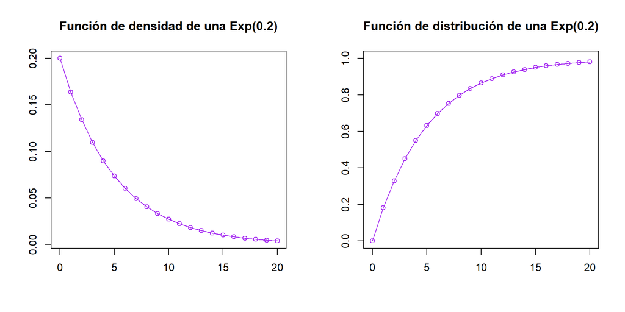

```r
par(mfrow = c(1,2))

#Función de densidad
plot(0:20, dexp(0:20,0.2),
     col = "purple",
     xlab = "", ylab = "",
     main = "Función de densidad de una Exp(0.2)",
     type = "o")

#Función de distribución
plot(0:20, pexp(0:20,0.2),
     col = "purple",
     xlab = "", ylab = "",
     main = "Función de distribución de una Exp(0.2)",
     type = "o",
     ylim = c(0,1))
```

```r
par(mfrow = c(1,1))
```

Ejemplos: el tiempo que pasa entre la llegada de un bus y otro en una parada de bus.

## 2. Distribución Exponencial en `R` y `Python`

El código de la distribución Exponencial:

- En **`R`** tenemos las funciones del paquete `stats`: **`dexp(x, rate), pexp(q, rate), qexp(p, rate), rexp(n, rate)`** donde `rate`$=\lambda$ es el tiempo entre dos sucesos consecutivos de la distribución.
- En **`Python`** tenemos las funciones del paquete **`scipy.stats.expon`**: **`pdf(k, scale), cdf(k, scale), ppf(q, scale), rvs(n, scaler)`** donde `scale`$=1/\lambda$ es la inversa del tiempo entre dos sucesos consecutivos de la distribución.

## 3. Ejemplos en código para la distribución Exponencial (R y Python)

Empleamos una lambda de 3, que represento 3 minutos en una parada de metro.

#### **Ejemplo en R**

Empleamos las funciones anteriores.

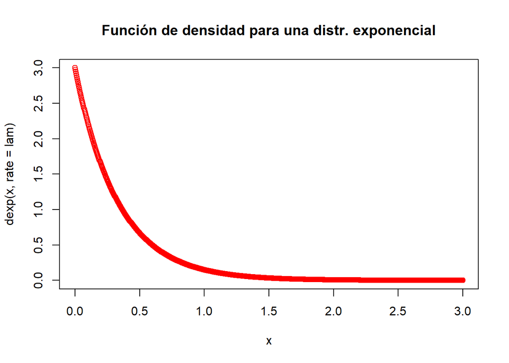

```r
#defino la lambda
lam = 3

#determino los valores de "x"
x = seq(0,3,length=1000)

#Función de densidad
plot(x, dexp(x, rate=lam), col="red",
     title("Función de densidad para una distr. exponencial"))
```

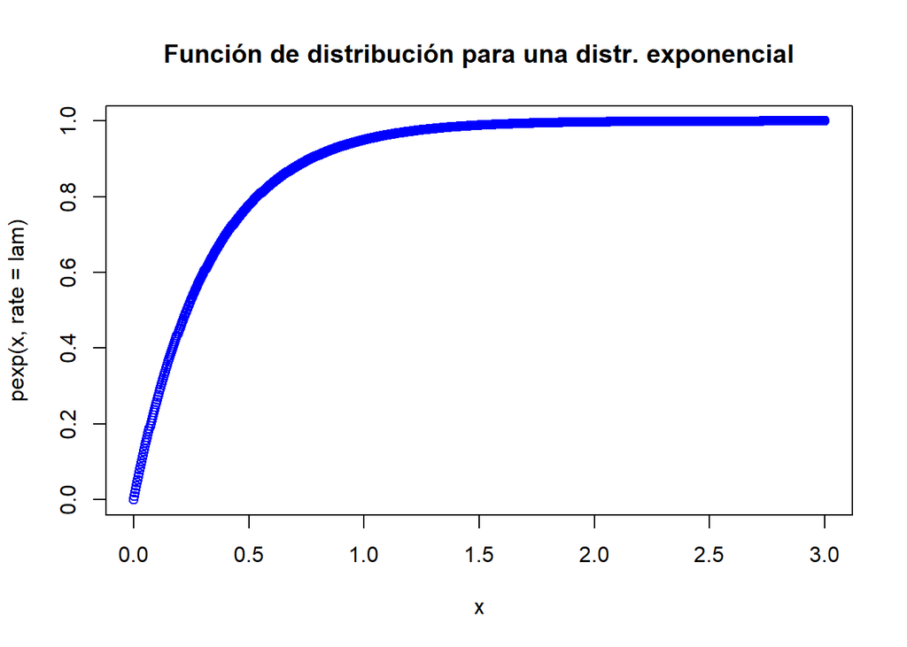

```r
#Función de distribución
plot(x, pexp(x, rate = lam),
     col="blue",
     title("Función de distribución para una distr. exponencial"))
```

```r
#La mediana
qexp(0.5, rate=lam)
```

```
## [1] 0.2310491
```

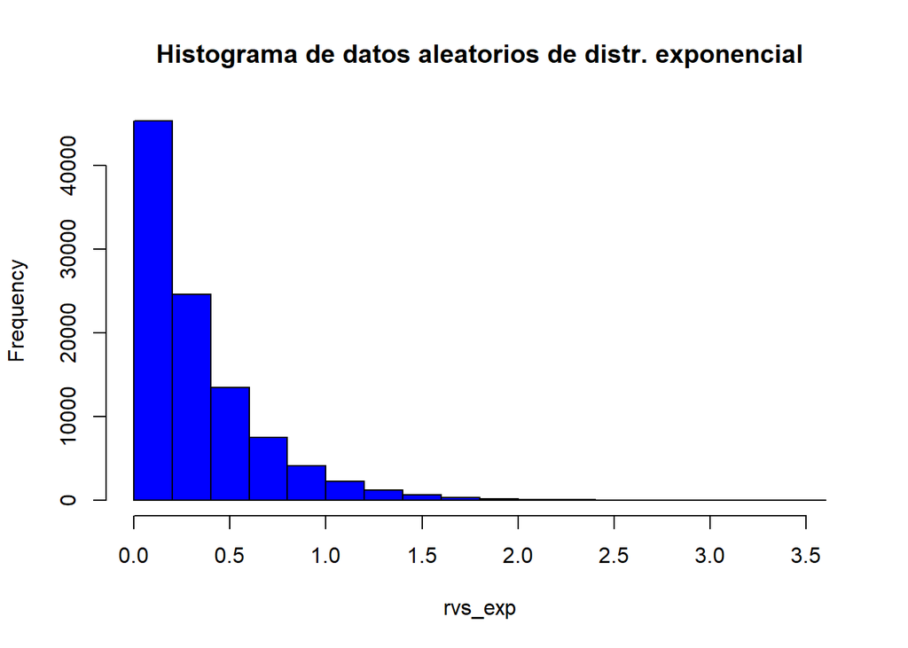

```r
#Crear nºs aleatorios y hacer el histograma
rvs_exp = rexp(100000, rate=lam)
hist(rvs_exp, col = "blue",
     main="Histograma de datos aleatorios de distr. exponencial")
```

#### **Ejemplo en Python**

Vete al script de Python del presente tema 14.